# Pizza Sales Analysis & Revenue Forecasting

Final Report

Jonathan Katz

2025-11-30

# Executive Summary

This report analyzes one year of pizza restaurant sales data (2015) to understand customer behavior and forecast future revenue.

**Forecast Performance:**

**Recommendations:**

1. Staff fully during peak hours (12pm and 5-7pm)
2. Run promotions on slow days (Sunday)
3. Ensure Classic Deluxe ingredients are always stocked
4. Incorporate holiday calendar into future forecasting models

# Business Questions

This analysis answers six key questions:

1. What will total sales revenue be for the next 7 days?
2. What are the peak hours for orders?
3. Which day of the week has the highest sales?
4. What is the best-selling pizza?
5. What is the most popular pizza size?
6. What is the average order value?

# Dataset Overview

**Source:** Kaggle Pizza Restaurant Sales Dataset

**Period:** January 1, 2015 - December 31, 2015

**Size:** 48,620 order line items

| Metric | Value |
| --- | --- |
| Total Orders | 21,350 |
| Total Pizzas Sold | 49,574 |
| Total Revenue | $817,860 |
| Unique Pizza Types | 32 |

# Key Findings

## What are the peak hours for orders?

[figure not shown]

**Answer:** Peak hours are **12pm (lunch)** and **5-7pm (dinner)**.

**Recommendation:** Ensure full staffing during these windows.

## Which day of the week has the highest sales?

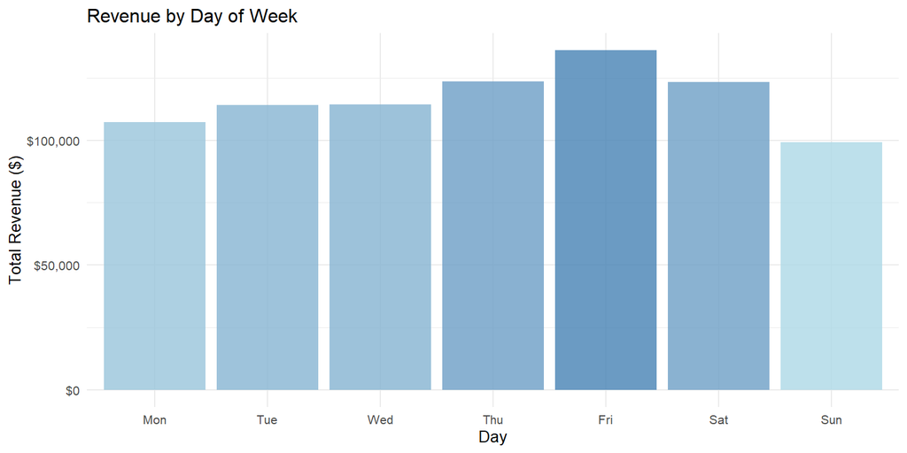

**Answer:** **Friday** has the highest sales. Sunday has the lowest.

**Recommendation:** Run promotions on slow days (Sunday) to increase traffic.

## What is the best-selling pizza?

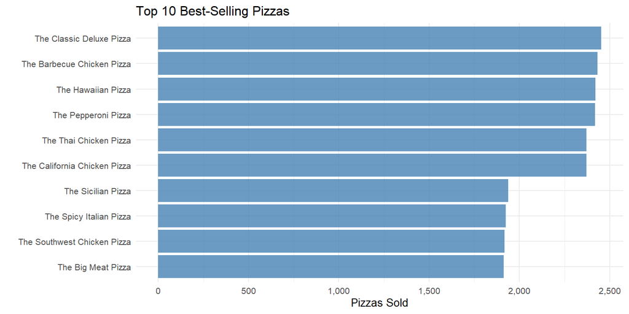

**Answer:** **The Classic Deluxe Pizza** is the best-seller.

**Recommendation:** Ensure ingredients for this pizza are always in stock.

## What is the most popular pizza size?

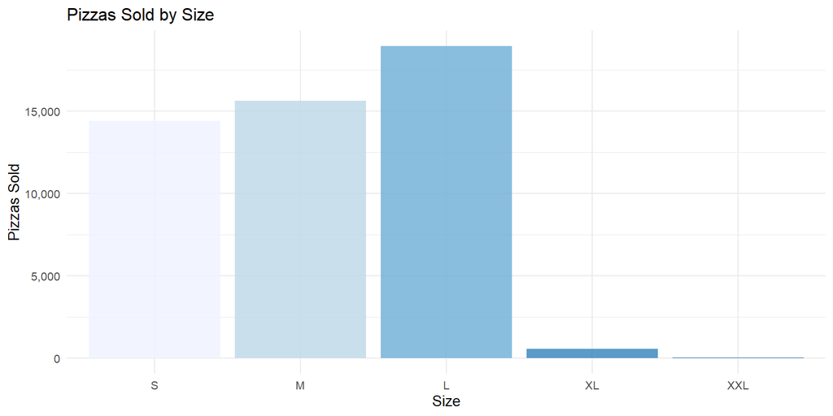

**Recommendation:** Optimize pricing and inventory around Large pizzas.

## What is the average order value?

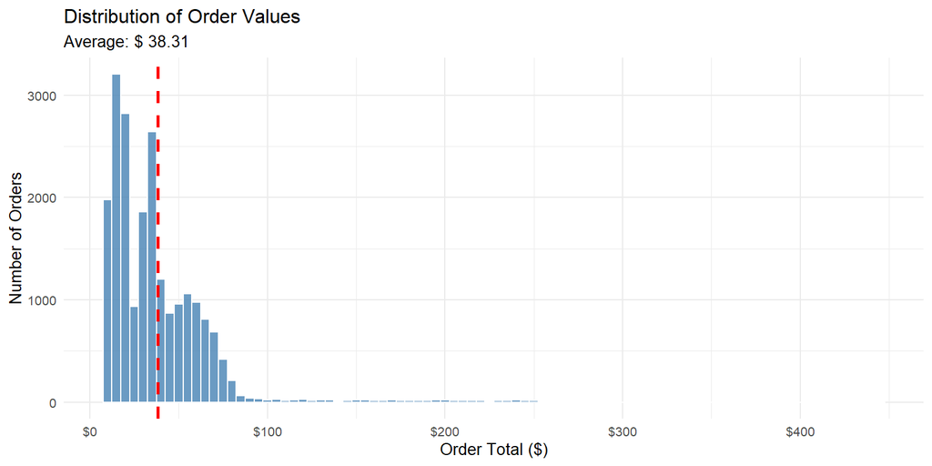

**Answer:** The average order value is **$38.31**.

**Recommendation:** Set delivery minimum at $35-40 to optimize operations.

# Revenue Forecast

## Daily Revenue Trend

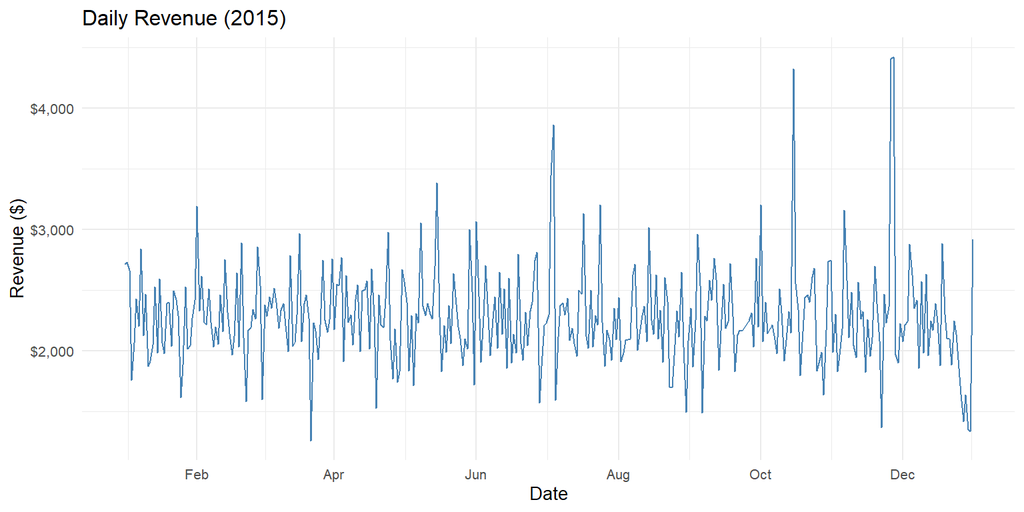

## 7-Day Forecast Model

We used an ARIMA model trained on 358 days of data to predict the final 7 days of the year.

[output not shown]

## Forecast Accuracy

| Metric | Value |
| --- | --- |
| MAE (Mean Absolute Error) | $670 |
| MAPE (Mean Absolute % Error) | 42.7% |

# Lessons Learned

## Why the Forecast Missed

**What happened:**

1. **Christmas Day closure** — Revenue dropped to zero when the restaurant was closed
2. **Post-holiday behavior** — Customers ate homemade food with family instead of ordering pizza
3. **Atypical demand** — The week between Christmas and New Year is not representative of normal business

**Why the model couldn’t predict this:**

- The model learned patterns from “typical” weeks throughout the year
- It had no information about holidays or special events
- Christmas only occurs once in the training data, so the model couldn’t learn this pattern

## How to Improve

For a production forecasting system, I would:

1. **Add a holiday calendar** — Flag holidays as a feature in the model
2. **Exclude anomalies** — Train on typical weeks, handle holidays separately
3. **Use a model designed for seasonality** — Facebook Prophet handles holidays explicitly
4. **Incorporate external data** — Weather, local events, promotions

This experience demonstrates that **understanding your data’s context is as important as the technical modeling.**

# Summary of Recommendations

| Finding | Recommended Action |
| --- | --- |
| Peak hours: 12pm, 5-7pm | Full staffing during peaks |
| Friday is best day | Maximize Friday capacity |
| Sunday is slowest day | Run Sunday promotions |
| Classic Deluxe is #1 | Stock Classic Deluxe ingredients |
| Large is most popular | Optimize Large pizza pricing |
| AOV is $38.31 | Set $35-40 delivery minimum |
| Forecast missed holidays | Add holiday features to model |

# Conclusion

This analysis provided actionable insights into pizza restaurant operations:

- Clear identification of peak hours and days for staffing optimization
- Product performance data for inventory management
- Average order value for pricing and promotion strategy
- A forecasting model with documented limitations and improvement path

The forecast’s failure during Christmas week turned into a valuable learning opportunity, demonstrating the importance of domain knowledge and contextual understanding in data analysis.

*Report generated on 2025-11-30*